# Tutorial Part II — R goes Spatial

```r
## this might be useful if rtools is not yet installed manually
#install.packages("installr")
#installr::install.rtools()
```

Let me start with a big thanks to Cedric Scherer, Moritz Wenzler, Pierre Gras and Juergen Niedballa who constantly helped to improve the course since its start in 2014! I am deeply indebted to you!

# Introduction

The course is intended to be a quick introduction to using R as a GIS. It builds on the previous course, Course1_RIntro, and is written in such a way that you can understand handling spatial data when knowing the basics of handling data.frames, matrices and lists. There is no need to know `tidyverse/dplyr` coding style.

This course provides the basics for using the most important spatial data types — vector data (points, lines, polygons, aka ESRI shapefiles) and raster data.

Recently, `{sf}` objects have been developed to handle vector data more easily. Those objects can be treated like simple `data.frames`. For raster data there are fast and modern packages — namely `{terra}` and `{stars}`. The `{terra}` package is also especially useful for remote sensing data; it has a single `SpatRaster` class. The course is updated to use the `{terra}` package.

In addition to different data types, the course provides sections on coordinate projections and the most important geo-spatial operations. Last but not least - we plot a lot of maps to ease data visualization and because it is fun.

The data we use stem from a longstanding project we run in Borneo. Please refer to our website https://ecodynizw.github.io/ for further information. The project involves species conservation and large scale landscape planning. To learn more about the data used in the course and the project, please refer to the following publications that are freely available:

- Targeted conservation to safeguard a biodiversity hotspot from climate and land-cover change. MJ Struebig, et al. 2015. Current Biology 25 (3), 372-378. https://doi.org/10.1016/j.cub.2014.11.067
- Anticipated climate and land‐cover changes reveal refuge areas for Borneo’s orang-utans. MJ Struebig, et al. 2015. Global Change Biology 21 (8), 2891-2904. https://doi.org/10.1111/gcb.12814
- The importance of correcting for sampling bias in MaxEnt species distribution models. S Kramer‐Schadt et al. 2013. Diversity and Distributions 19 (11), 1366-1379. https://doi.org/10.1111/ddi.12096
- The Borneo carnivore database and the application of predictive distribution modelling. S Kramer-Schadt, et al.2016. Raffles Bulletin of Zoology, Supplement No. 33: 18–41. https://lkcnhm.nus.edu.sg/app/uploads/2017/06/S33rbz018-041-1.pdf

## Useful (web)sites

**1. R news and tutorials**

- http://www.r-bloggers.com/

**2. Quick introduction to spatial R**

- https://rspatial.org/
- https://r-spatial.org/

**3. Spatial visualisation**

- check out the packages `{tmap}`, `{ggmap}`, `{leaflet}` and `{cartography}`
- https://r-tmap.github.io/tmap/
- A whole book: https://clauswilke.com/dataviz/ with spatial data here: https://clauswilke.com/dataviz/geospatial-data.html
- and my all-time favourite: https://www.cedricscherer.com/

**4. Overview of spatial packages**

- http://cran.r-project.org/web/views/Spatial.html =  
  http://cran.r-project.org/view=Spatial

**5. R-cheatsheets — great for learning ‘vocabulary’**  
* e.g. here: https://www.rstudio.com/resources/cheatsheets/ and click on ‘contributed cheatsheets’

**6. Infos about simple features in R (`{sf}` package)**

- https://r-spatial.github.io/sf/index.html
- and nice intro: https://oliviergimenez.github.io/intro_spatialR/#1
- geocomputation: https://geocompr.robinlovelace.net/spatial-operations.html

**7. Lots of EPSG Codes for map projections**  
* Use EPSG codes as unique and specific identifies of your coordinate reference systems instead of writing projection details.  
* for EPSG codes see http://spatialreference.org/ or https://www.nceas.ucsb.edu/~frazier/RSpatialGuides/OverviewCoordinateReferenceSystems.pdf

**8. Data analysis specials:**

- For analysis of plot-based biodiversity data: package `{vegan}`
- For analysis of telemetry data: packages `{adehabitatHR}`, `{adehabitatLT}`, `{move}`, `{recurse}`, `{momentuHMM}`, `{moveHMM}`, `{ctmm}`

## Further reading

**1. Check Roger Bivand’s publications:**  
* http://cran.r-project.org/web/views/Spatial.html  
* *THE* https://r-spatial.org/book/

**2. Check Edzer Pebesma’s course materials and publications:**  
* https://www.uni-muenster.de/Geoinformatics/institute/staff/index.php/119/edzer_pebesma  
* https://edzer.github.io/UseR2017/

**3. Geocomputation with R: a open-access book of Robin Lovelace, Jakub Nowosad & Jannes Muenchow**  
* https://geocompr.robinlovelace.net

**4. DataVizArt Cedric Scherer -> check out his #TidyTuesday or #30DaysMapChallenge contributions**  
* https://www.cedricscherer.com/top/dataviz/  
* Codes: https://github.com/z3tt/TidyTuesday and https://github.com/z3tt/30DayMapChallenge

# Basics

## How to install…

```r
pkgs <- c("terra", "stars", "sf", "sp", "rasterVis",
          "ggplot2", "tmap", "viridis", "patchwork", "here", "units",
          "devtools", "osmdata", "elevatr","jpeg")

## install packages that are not installed yet
## (not important to understand the following code, just run it)
unavailable <- setdiff(pkgs, rownames(installed.packages()))
install.packages(unavailable)

## -------- Please run the following ---------------------
## install development version of rnaturalearth as currently the
## download doesn't work in the CRAN package version
#devtools::install_github("ropensci/rnaturalearth")

## install rgeoboundaries from GitHub (not available on CRAN yet)
#devtools::install_github("wmgeolab/rgeoboundaries", force = TRUE)
```

## …and load packages

```r
## when working with spatial data
## do NOT load both packages {terra} and the old {raster} at the same time,
## as this creates problems with the namespace!!!
library(terra)
library(rasterVis)

## working with vector data
library(sf) ## the "new" {sp} package
library(sp) ## the old one. Still has some nice functionalities
library(stars)

## visualization
library(ggplot2)
library(tmap)
library(viridis) ## nice colour palettes
library(patchwork) ## to combine plots

library(units) ## handle measurement data
library(here) ## for easy directory management

## depending on the sequence of installation
## you might need to reinstall this. But wait for an error message.
#install.packages("Rcpp", repos="https://rcppcore.github.io/drat")
```

## How to call help

Remember to use ‘?’ or ‘??’ if you want information about a function of package. If you do not understand some of the code below, always check the arguments and help of the function. Vignettes are helpful code demonstrations with examples.

```r
## Information about a function or a package.
?terra

## search for an item:
??SpatialPolygons

## show the instructions of a package:
vignette(package = "sf") # vignette(package="sp")

## load the instruction of a package (embedded pdf):
vignette("sf1")

## For a better version of the sf vignettes see
# https://r-spatial.github.io/sf/articles/
```

## Using the namespace

Important is setting the namespace. Sometimes, packages use the same name for a function that does different things (like *plot*), so it is helpful to set the namespace with a :: . That is, provide the library/ package from which you want to use the function with ‘package::function’.

```r
terra::plot() ## the :: provides the namespace,
              ## i.e. that the function 'plot' is from the terra-package
```

## Set the workspace

If you have downloaded the repository for the course as described here (https://ecodynizw.github.io/teaching.html), you automatically have adopted our folder structure. Nothing more to do! Continue with chapter ‘`R-projects` and package `{here}`’.

**Click here for optional - use own course folder setup and R-project**

### Optional - setting workspace by hand and learn about R-projects

If you have not downloaded the course folder structure with the R-project, you can also do it ‘manually’: Set your root directory , e.g. the directory under which you store everything you need for this course, like the data and the R-Scripts, with `setwd()`. You could name it ‘d6_teaching_collection’.

Create the subfolders relative to root-folder. Please adjust to your setup. A possible folder structure could be:

```bash
.
└── <your folder name>                    ─ root folder , e.g. d6_teaching_collection
    ├── data                              ─ data
    │   └── data_borneo                   ─ e.g., the Borneo data
    │       ├── geo_raster_current_asc    ─ geo data, raster ascii format, as in data_borneo
    │       └── animal_data
    └── R                                 ─ store here all your scripts, i.e.
        ├── my_script_course1.R
        └── my_script_course2.R
```

Traditionally, the working directory was ‘hard coded’, i.e. the full path was specified with setting the work directory by `setwd()`.

```r
## adjust the working directory [wd]
## getwd()  ## check where you are
##
## ## Set your OWN root directory, the following is just an example of how to do it:
## #root_wd <- setwd("C:/Users/kramer/d6_teaching_collection")
```

This approach is error-prone and it complicates the cooperation with others as they have to update the working directory in every script they receive from you. (And if they don’t change it back to your directory, you also have to update it again…)

Nowadays, the best approach is to work with [R projects](https://support.rstudio.com/hc/en-us/articles/200526207-Using-RStudio-Projects) that are associated with own working directory, workspace, history, and source documents.

You can create a project in the RStudio IDE by using the `Create Project` command (available on the Projects menu and on the global toolbar). In our case, we want to create a project in an existing directory where there is already R code and data placed inside that given folder. Now, a hidden folder called `.Rproj.user` and most importantly a file called `your_project.Rproj` should appear in your folder. Every time you want to work on your project, you open the Rstudio session by double-clicking on that `.Rproj` file, which ensures that the root working directory is correctly set.

End of optional.

### `R-projects` and package `{here}`

When using R projects, the package `{here}` is a handy helper:

The goal of the `{here}` package is to enable easy file referencing in project-oriented workflows. In contrast to using `setwd()`, which is fragile and dependent on the way you organize your files (see optional section above for details), `{here}` uses the top-level (=root) directory of an `R-project` to easily build paths to files.

The `here()` function from the `{here}` package searches for the `.Rproj` file and will allow you to construct relative paths easily within your project environment:

```r
# tip: use the namespace here:: before calling to function here()
# because here() alone interferes with the package `purrr` if that is loaded
here::here()
```

```
## [1] "C:/Users/wenzler/Documents/GitHub/d6_teaching_collection"
```

```r
here::dr_here()

# this is an example, ob how a long folder path can be assigned to a short name (root_wd)
root_wd <- here::here() # the root folder is automatically set
root_wd
```

```
## [1] "C:/Users/wenzler/Documents/GitHub/d6_teaching_collection"
```

Now, we assign the path to these folders that contain our data relative to the root directory, and we work with the Borneo data:

```bash
.
└── root_wd                    ─ e.g. d6_teaching_collection
    └── dbor_wd                ─      data / data_borneo
        ├── maps_wd            ─      geo data
        └── anim_wd            ─      animal location data
```

```r
## Now, create the linkages to the folders:

# dbor_wd     <- paste0(root_wd, "/", "data/data_borneo") ## the old way to define the path from the root
dbor_wd     <- here("data","data_borneo") #- note the nested folder structure

# maps_wd   <- here("data","data_borneo","geo_raster_current_asc")  ##  same as:
maps_wd   <- paste0(dbor_wd, "/geo_raster_current_asc")

## mind difference paste0() and paste() :
## paste() needs a separator sign, in this case no space ''
vecs_wd   <- paste0(dbor_wd, "/geo_vector")
anim_wd   <- paste(dbor_wd, "/animal_data", sep = '')
```

Create an output folder where you can temporarily store your results (anything you plot, create, want to save,….) with *dir.create*. If you use our downloaded course repository, you already have this folder.

```r
output_wd <- here("output") # assign the path name
output_wd ## check
```

```
## [1] "C:/Users/wenzler/Documents/GitHub/d6_teaching_collection/output"
```

```r
if (!dir.exists(output_wd)) dir.create(output_wd) # create only if directory does NOT! exist
```

Finally, your folder structure will look like this:

```bash
.
└── <your folder name>               ─ root folder , e.g. d6_teaching_collection
    ├── data                         ─ data
    │   ├── data_borneo              ─ e.g., the Borneo data
    │   ├── geo_raster_current_asc   ─ geo data, raster ascii format, as in data_borneo
    │   └── animal_data
    ├── R                            ─ store here all your scripts, i.e.
    │   ├── my_script_course1.R
    │   └── my_script_course2.R
    ├── output                       ─ for any results/ plots,...
    └ <your R project name.Rproj>    ─ in case you are working with an R-Project
```

A small yet important hint on file and folder naming: Do NOT! use dots (NOT: folder.name), spaces, comma, semicolon, or any special signs like ö, ä, ü, ß, ! etc. in your folder names, and keep name length at a maximum of 13 letters!

## Access folder content

You will find a lot of bioclimatic raster files (.asc) in the *geo_raster_current_asc* folder, which we named `maps_wd` above:

```r
## create an object called 'filename' and store the names of the files
filenames <- list.files(path = maps_wd)

## show the first six files
head(x = filenames)
```

```
## [1] "bio_asc_01.asc" "bio_asc_21.asc" "bio_asc_22.asc" "bio_asc_24.asc"
## [5] "bio_asc_27.asc" "bio_asc_42.asc"
```

```r
## if you want to see all stored files, use
# filenames
```

Should this directory be empty, then you have wrongly set the root directory and the data directory. Please check again how your folder structure looks like. By default, this folder should contain six ascii-files. The description what info these maps contain is provided in the *DataDescription_Borneo.doc* in the *data_borneo* folder that you downloaded with the repository.

## Recap from Course 1 Basics in R

**useful functions:**

- `head()`: only shows the first 6 elements, i.e. if you have a large data frame, you can quickly check header and the first entries (analogously: `tail()`)
- `paste(x, sep='')`: appends characters or numbers — great for working directories, loops across many maps or data.frames etc

**data formats and access:**

- `data.frame()`: [row, column] or “dollar sign”, i.e. `mydata[1,2]` → first row, second column, or `mydata$MyColumnName[1]`
- `matrix()`: see above
- `list()`: [[element]], i.e. `mylist[[1]]`. Attention! A list element can consist of a data.frame that you can then access like that: `mylist[[1]][1,2]`…

*S4-objects* (like spatial data)

- access via `@`, i.e. `SpatRaster@data@values`

# Raster data

## Data import

First, load a raster map. Please check the description in the folder called *DataDescription_Borneo.doc*. The file *bio_asc_01.asc* is showing mean annual temperature multiplied by 10. Why? Because it can be stored as integer, not floating type (i.e. with digits), which saves a lot of storage and memory.

```r
## ## read the ascii file as raster format
ras_bio_asc_01 <- terra::rast(x = paste0(maps_wd, "/bio_asc_01.asc"))

## or use function 'here' (which in this case is much longer.....)
# ras_bio_asc_01 <- terra::rast(x = here("data", "data_borneo","geo_raster_current_asc", "bio_asc_01.asc"))

## copy the raster map and give it a sensible name
Bor_mat <- ras_bio_asc_01  ## easy copying of whole maps; mat stands for mean annual temp
```

Now have a look at the object:

```r
Bor_mat
```

```
## class       : SpatRaster
## size        : 1425, 1423, 1  (nrow, ncol, nlyr)
## resolution  : 0.008333334, 0.008333334  (x, y)
## extent      : 108.3341, 120.1925, -4.374013, 7.500988  (xmin, xmax, ymin, ymax)
## coord. ref. : lon/lat WGS 84 (CRS84) (OGC:CRS84)
## source      : bio_asc_01.asc
## name        : bio_asc_01
```

What does the slot with *extent* tells you? Looks like coordinates in decimal degrees, i.e. latitude and longitude.

Now have a look at the slot `coord. ref.` (or `crs`. CRS stands for **c**oordinate **r**eference **s**ystem): Nicely in the new `{terra}`-package, the CRS (map projection) is automatically set in the following way: If the `crs` argument is missing when loading data with `rast(x= ..., crs= ...)`, and the x coordinate values are within -360 .. 360 and the y coordinate values are within -90 .. 90, **automatically** “+proj=longlat +datum=WGS84” is assigned. WGS84 is the global reference system for geospatial information and is the reference system for the Global Positioning System (GPS). In this case, (OGC:CRS84) stands for ‘Open Geospatial Consortium’ OGC standards to represent the coordinate reference system WGS84. The parameters for this CRS are now stored in so-called ‘well-known text’ (WKT) files. We will come back to that later.

However, sometimes the slot `coord. ref.` is empty, i.e. if other coordinates than decimal degrees are used, e.g. UTM. That means, without knowing the reference system, the map cannot be plotted at the exact location on the globe. Thus, when you get a map, always make sure you also get the information of the coordinate reference system! If it is not yet set/ assigned (because you import a raster map as a simple matrix or points from a file), this is the first thing you should do!

```r
# str(Bor_mat) ## check this
crs(Bor_mat)   ## crs = coordinate reference system. If empty, assign it!
```

```
## [1] "GEOGCRS[\"WGS 84 (CRS84)\",\n    DATUM[\"World Geodetic System 1984\",\n        ELLIPSOID[\"WGS 84\",6378137,298.257223563,\n            LENGTHUNIT[\"metre\",1]]],\n    PRIMEM[\"Greenwich\",0,\n        ANGLEUNIT[\"degree\",0.0174532925199433]],\n    CS[ellipsoidal,2],\n        AXIS[\"geodeti…
```

In this case, it was automatically assigned, so nothing to do for now.But see later, when we do not have a geographic CRS underlying the map….

## Assign the CRS

*Important!* Please read and repeat basic GIS-knowledge on coordinate reference systems (CRS), map projections, and geographic and projected coordinates. This issue is also covered in the lecture prior to this course for TUB students.

If a map already has a defined CRS, then you cannot simply overwrite this! To re-calculate the coordinates from one system into another system (e.g. from angular coordinates of latitude/ longitude of WGS84 to a projected CRS with planar coordinates and meter distances, equal area of Lambert Azimuthal), you need to *transform* it with the function `project()`(raster-data) or `st_transform()`(vector-data) (see chapters below).

In the following, we assign the CRS only when no information is provided. This can be the case when you upload a map based on a simple `data.frame` or `matrix`, i.e. when it is not yet a spatial object.

`crs(<raster>)` gives the information of the object (here: raster layer) `Bor_mat` or `ras_bio_asc_01`, and is also used to set the CRS of the object via assignment: `crs(<raster>) <- <projection>`.

- `crs(<raster>)` shows coordinate reference system of a spatial object
- `crs(<raster>) <- <projection>` creates projection and sets arguments for CRS!

An easy way to specify the CRS is using a unique identifier system, where all parameters of the projections are stored. A well-known identifier (WKID) is the EPSG code. E.g. instead of `"+proj=longlat +datum=WGS84"` use `"+init=epsg:4326"`.

See http://spatialreference.org/. The EPSG code for WGS84 is 4326.

In case the CRS was not yet assigned:

```r
## many ways to assign the CRS, options listed below:
crs(ras_bio_asc_01) <- "+proj=longlat +datum=WGS84"
crs(ras_bio_asc_01) <- "+init=epsg:4326"
```

Projections can also be transferred from one object to another, but only when the CRS hasn’t yet been specified and the coordinates are stemming from the same system, i.e. longitude/ latitude.

In the following, load the topographic map (digital elevation model) of Borneo (`Bor_dem.asc` or `bio_asc_24.asc`) and assign it the same CRS as `Bor_mat`, because we know they are overlaying (you can check that with the raster extents):

```r
## ras_bio_asc_24 = DEM = digital elevation model
ras_bio_asc_24 <- rast(x = paste0(maps_wd, "/bio_asc_24.asc"))

crs(ras_bio_asc_24)
```

```
## [1] "GEOGCRS[\"WGS 84 (CRS84)\",\n    DATUM[\"World Geodetic System 1984\",\n        ELLIPSOID[\"WGS 84\",6378137,298.257223563,\n            LENGTHUNIT[\"metre\",1]]],\n    PRIMEM[\"Greenwich\",0,\n        ANGLEUNIT[\"degree\",0.0174532925199433]],\n    CS[ellipsoidal,2],\n        AXIS[\"geodeti…
```

```r
## if not assigned, it could also be copied:
# crs(ras_bio_asc_24) <- crs(ras_bio_asc_01)
## same as:
# crs(ras_bio_asc_24) <- crs("+proj=longlat +datum=WGS84")
```

Quickly visualize the data with the easy base plot:

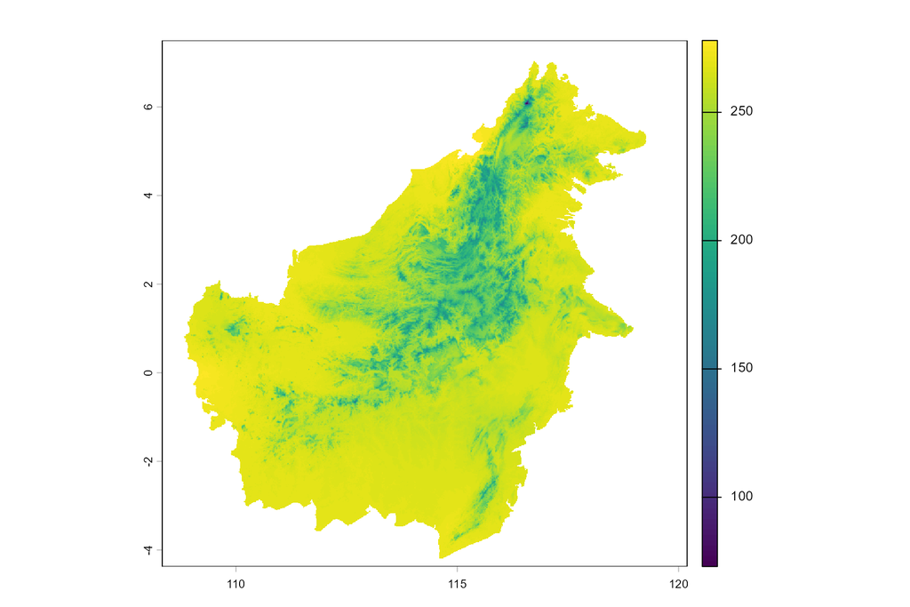

```r
## base plot
plot(x = ras_bio_asc_01)
```

(More plotting later!)

## Clip areas

We do this first to work with a small raster to save computation time. For this, we create a clip_extent based on the spatial coordinates. The command/ function `crop()` then clips the raster map.

```r
ext(x = ras_bio_asc_01) ## get the extent
```

```
## SpatExtent : 108.33412288693, 120.19245688433, -4.3740129986358998, 7.5009876663641002 (xmin, xmax, ymin, ymax)
```

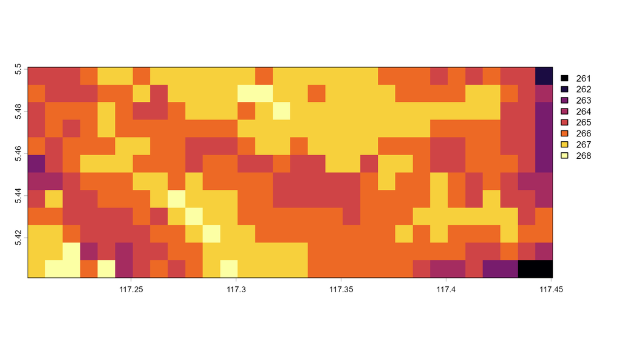

```r
clip_extent <- ext(117.2, 117.45, 5.4, 5.5) ## create a subset based on long/ lat coordinates
ras_bio_asc_01_cr <- crop(x = ras_bio_asc_01, y = clip_extent)

plot(ras_bio_asc_01_cr, col = viridis::inferno(10))
```

## Accessing *SpatRaster* objects

First, have a look at the internal data structure of the raster object:

```r
ras_bio_asc_01_cr
```

```
## class       : SpatRaster
## size        : 12, 30, 1  (nrow, ncol, nlyr)
## resolution  : 0.008333334, 0.008333334  (x, y)
## extent      : 117.2008, 117.4508, 5.400988, 5.500988  (xmin, xmax, ymin, ymax)
## coord. ref. : lon/lat WGS 84
## source(s)   : memory
## varname     : bio_asc_01
## name        : bio_asc_01
## min value   :        261
## max value   :        268
```

```r
## get additional information:
# str(ras_bio_asc_01_cr) ## strucutre of object
# attributes(ras_bio_asc_01_cr) ## available slots
# class(ras_bio_asc_01_cr) ## object type in R
```

There are many ways to retrieve internal data and access single bits of information:

```r
## spatial extent
ext(ras_bio_asc_01_cr)
```

```
## SpatExtent : 117.20079005013, 117.45079006412999, 5.4009875487641006, 5.5009875543641007 (xmin, xmax, ymin, ymax)
```

```r
xmin(ras_bio_asc_01_cr) ## or: xmin(ext(ras_bio_asc_01_cr))
```

```
## [1] 117.2008
```

```r
ncol(ras_bio_asc_01_cr)
```

```
## [1] 30
```

```r
head(ras_bio_asc_01_cr)
```

```
##   bio_asc_01
## 1        265
## 2        265
## 3        265
## 4        266
## 5        267
## 6        267
```

```r
crs(ras_bio_asc_01_cr) ## != CRS(ras_bio_asc_01_cr) ## mind the spelling in capital letters
```

```
## [1] "GEOGCRS[\"WGS 84\",\n    ENSEMBLE[\"World Geodetic System 1984 ensemble\",\n        MEMBER[\"World Geodetic System 1984 (Transit)\",\n            ID[\"EPSG\",1166]],\n        MEMBER[\"World Geodetic System 1984 (G730)\",\n            ID[\"EPSG\",1152]],\n        MEMBER[\"World Geodetic Syste…
```

```r
## crs = coordinate reference system defined
## CRS creates projection and takes args for crs!
## e.g.
wgs84_crs_args <- CRS("+proj=longlat +datum=WGS84")
wgs84_crs_args  ## please check! You will see the WKT representation of the parameters
```

```
## Coordinate Reference System:
## Deprecated Proj.4 representation: +proj=longlat +datum=WGS84 +no_defs
## WKT2 2019 representation:
## GEOGCRS["unknown",
##     DATUM["World Geodetic System 1984",
##         ELLIPSOID["WGS 84",6378137,298.257223563,
##             LENGTHUNIT["metre",1]],
##         ID["EPSG",6326]],
##     PRIMEM["Greenwich",0,
##         ANGLEUNIT["degree",0.0174532925199433],
##         ID["EPSG",8901]],
##     CS[ellipsoidal,2],
##         AXIS["longitude",east,
##             ORDER[1],
##             ANGLEUNIT["degree",0.0174532925199433,
##                 ID["EPSG",9122]]],
##         AXIS["latitude",north,
##             ORDER[2],
##             ANGLEUNIT["degree",0.0174532925199433,
##                 ID["EPSG",9122]]]]
```

```r
## Retrieve internal data cont.:
nrow(x = ras_bio_asc_01_cr) # ncell(ras_bio_asc_01_cr)
```

```
## [1] 12
```

```r
dim(x = ras_bio_asc_01_cr)  ## 12 rows, 30 columns, 1 z-dimension
```

```
## [1] 12 30  1
```

```r
res(x = ras_bio_asc_01_cr)  ## resolution = cell size
```

```
## [1] 0.008333334 0.008333334
```

Any idea what this kind of strange cell size could be? We will come to that later.

An important function is `crds()`, which returns the centroids of each raster cell:

```r
head(x = crds(ras_bio_asc_01_cr), n = 10)
```

```
##              x        y
##  [1,] 117.2050 5.496821
##  [2,] 117.2133 5.496821
##  [3,] 117.2216 5.496821
##  [4,] 117.2300 5.496821
##  [5,] 117.2383 5.496821
##  [6,] 117.2466 5.496821
##  [7,] 117.2550 5.496821
##  [8,] 117.2633 5.496821
##  [9,] 117.2716 5.496821
## [10,] 117.2800 5.496821
```

## Terrain computation

We will now work with the digital elevation model (DEM) `ras_bio_asc_24`, where each raster cell is the height above sea level.  
.

Slope = steepness or degree of incline of a surface,influences water flow and erosion. Aspect = compass direction that a slope faces, measured in degrees clockwise from north (e.g., 0° is north, 90° is east, 180° is south, 270° is west). E.g. important for sunlight exposure.

Both are fundamental topographical characteristics used together to describe terrain and are widely applied in fields like geography, land development, and environmental science.

Further reading: https://gisnavigator.co.uk/slope-and-aspect-terrain-analysis/ or https://zia207.quarto.pub/digital-terrain-analysis.html

for visualisation, we will create a hillshade (3D look) based on topography using slope and aspect: - simulates a 3D surface - computes shaded relief values for a raster surface

```r
slope <- terrain(x = ras_bio_asc_24, v = "slope", unit = "radians", neighbors = 8)
aspect <- terrain(x = ras_bio_asc_24, v = "aspect", unit = "radians", neighbors = 8)
Bor_hs <- shade(slope, aspect, angle = 45, direction = 270)
```

Let’s plot the hillshade:

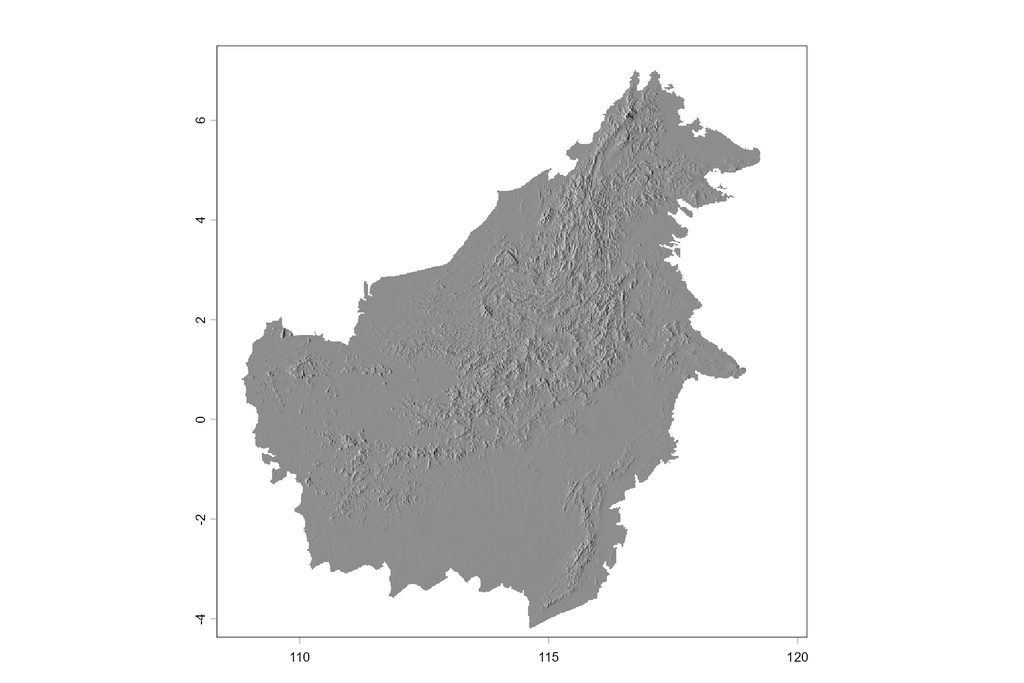

```r
plot(Bor_hs, col = grey(0:100/100), legend = FALSE)
```

Based on elevational maps, also a viewshed-analysis can be performed.  
https://rdrr.io/cran/terra/man/viewshed.html

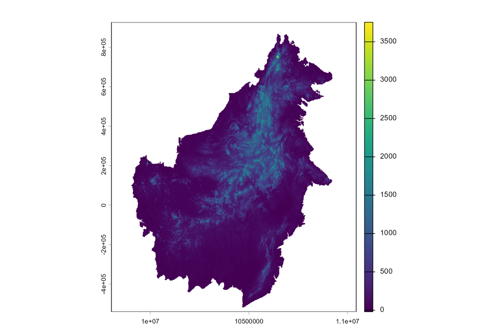

```r
bor_dem_proj      <- project(ras_bio_asc_24, "+proj=moll +lat_0=65 +lon_0=10")
## see chapter below for explanation
plot(bor_dem_proj) ## check dimension of x and y coordinates and choose center
```

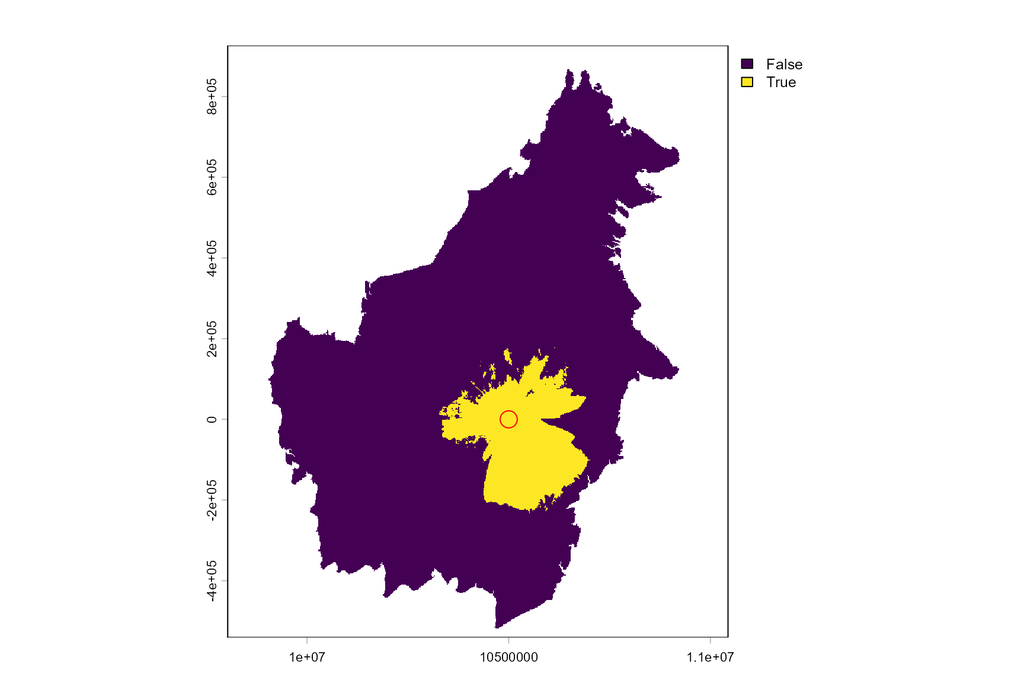

```r
observer_location <- cbind(10500000 , 0) ## 0 is equator

observer_height   <- 500 ## height above the elevation data of the observer
target_height     <- 1000 ## height above the elevation data of the targets


vs_raster <- terra::viewshed(x = bor_dem_proj,
               loc = observer_location,
               observer = observer_height,
               target= target_height,
               curvcoef = 0.85714)

plot(vs_raster)
points(observer_location[2] ~ observer_location[1], col='red', cex = 2)
```

Other very useful terrain calculations are cost surfaces, cost distances and least cost path, e.g. for corridor calculations. We will do that in another course.

## Visualising rasters

Above we used the basic `plot()` function, but there are pretty alternatives available.

### Easy to use: the `{tmap}` package

#### Static map

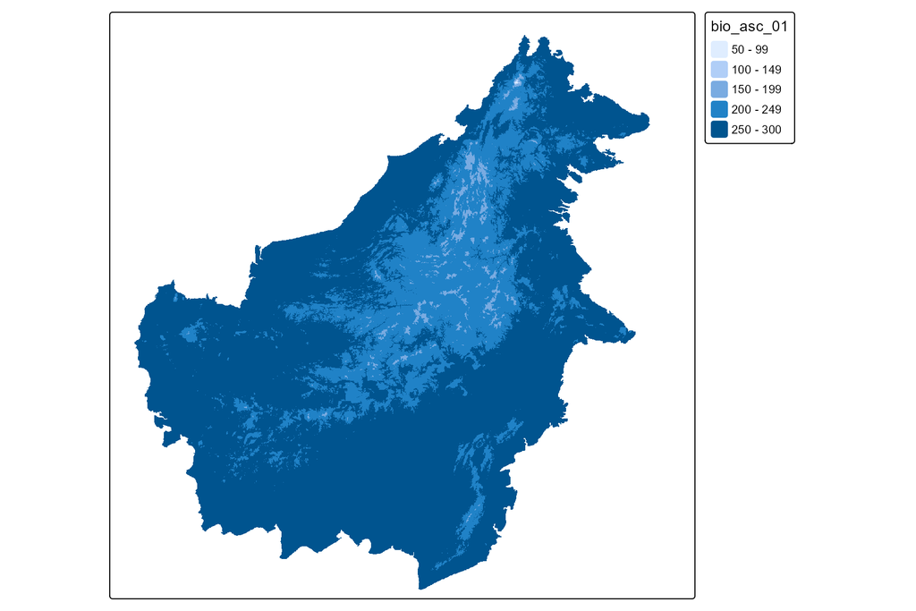

```r
tmap_mode(mode = "plot")
tm_shape(shp = ras_bio_asc_01) + tm_raster()
```

If you want to use a static map as high quality plots for your publication, save the output via `tmap_save()`.

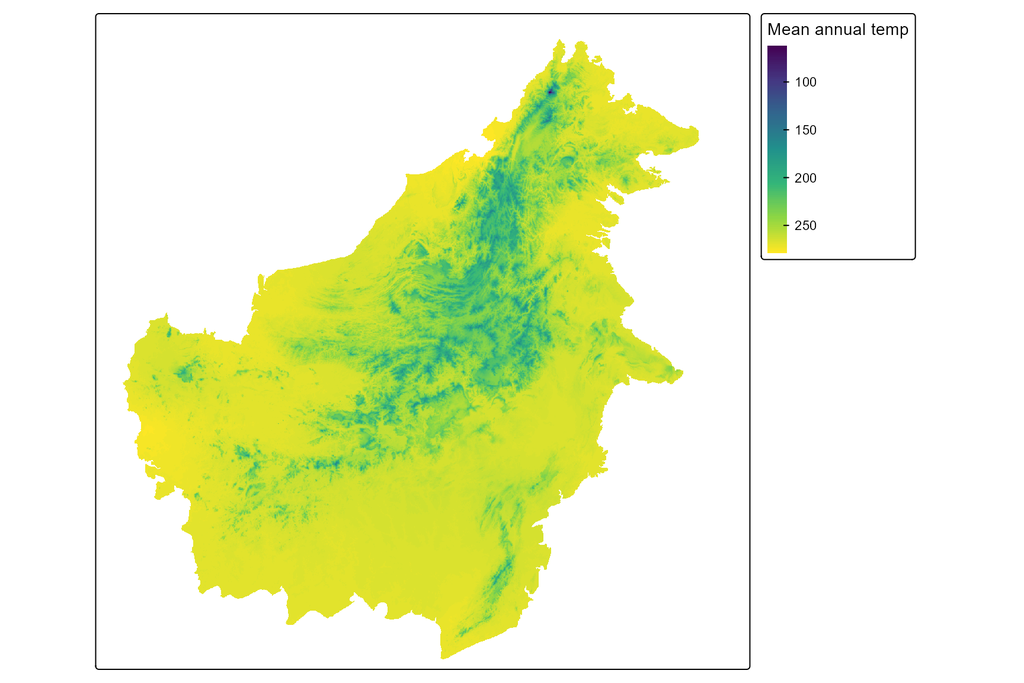

```r
tmap_mode("plot")

m <- tm_shape(ras_bio_asc_01) +
  tm_raster(
    col.scale  = tm_scale_continuous(values = "viridis"),
    col.legend = tm_legend(title = "Mean annual temp")
  )

m
```

```r
## old V3 style
#(m <- tm_shape(ras_bio_asc_01) +
#  tm_raster(palette = "viridis",  title = "Mean annual temp"))
```

Make sure that the quality is sufficient by setting the dpi (“dots per inch”) to at least 600. We save this map in our output folder.

```r
tmap_save(m, paste0(output_wd, "/BorneoMap_4326_tmap.png"),
          units = "mm", width = 90, height = 90, dpi = 600)
```

The saved map: check output folder

#### Interactive map

Very good for checking the correct location of the data. Great for zooming in/ out or overlaying with open street map data:

```r
tmap_mode(mode = "view")
tm_shape(shp = ras_bio_asc_01) + tm_raster(col_alpha=0.5)
```

[interactive chart not shown]

Click on the + | - | layer icons on the upper left and zoom in or out and change the background layers by clicking on the layer icon. The ‘alpha’ argument makes the layer transparent.

If you like, you can save the interactive map — check your output folder for the html file.

Tip of the day: always save the epsg code of your crs at the end of a spatial file name.

```r
tmap_mode("view")

## store it as object i.m and then save it
(i.m <- tm_shape(ras_bio_asc_01) +
  tm_raster(
    col.scale  = tm_scale_continuous(values = "viridis"),
    col.legend = tm_legend(title = "Mean annual temp")
  )
)
```

[interactive chart not shown]

```r
tmap_save(i.m, paste0(output_wd,"/BorneoMAT_4326.html"))
## or use here:
# tmap_save(i.m, here("output","BorneoMAT_4326.html"))
```

**Optional - Visualising rasters with the `{ggplot2}` package**

### Visualising rasters with the `{ggplot2}` package

For advanced R-users familiar with `ggplot()` coding style: Beautiful plots can also be made with `{ggplot2}`; however, `SpatRaster` objects cannot directly be plotted. One can use the [`{stars}` package](https://r-spatial.github.io/stars/).

The [`{stars}` package](https://r-spatial.github.io/stars/) is another package aimed at working with spatial data, namely spatio-temporal arrays (such as raster and vector data cubes). We first turn our raster into a `stars` object using function `st_as_stars` and can then use the `geom_stars()` function in combination with `ggplot`:

```r
stars_bio_asc_01 <- st_as_stars(ras_bio_asc_01)
class(stars_bio_asc_01)
```

```
## [1] "stars"
```

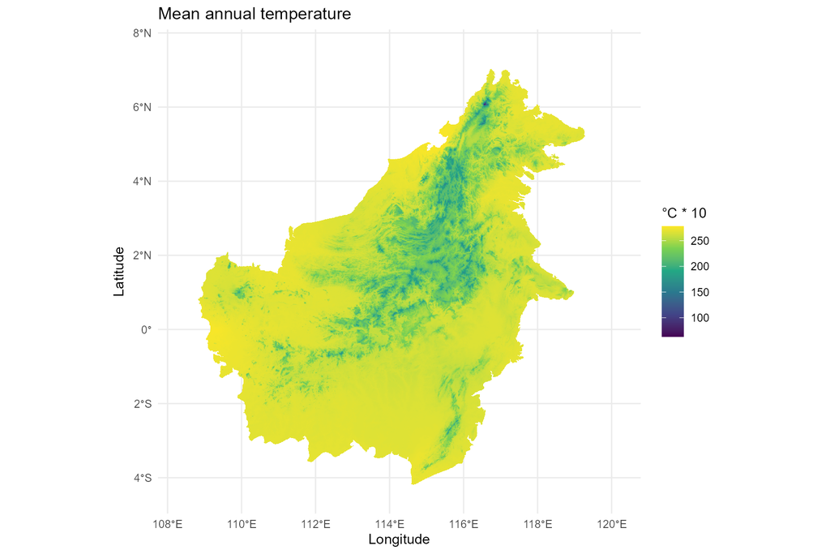

```r
g <- ggplot() +
  geom_stars(data = stars_bio_asc_01) +
  scale_fill_viridis_c(name = "°C * 10", na.value = "transparent") +
  coord_sf(crs = "EPSG:4326") + ## set correct projection
  labs(x = "Longitude", y = "Latitude",
       title = "Mean annual temperature") +
  theme_minimal() ## set custom plot style

g
```

The nice thing about ggplot is the flexibility to customize your plot further. Thus it is very suitable to create static high-quality maps for publication which can be saved via `ggsave()`. Make sure that the quality is sufficient by setting the dpi (“dots per inch”) to at least 600.

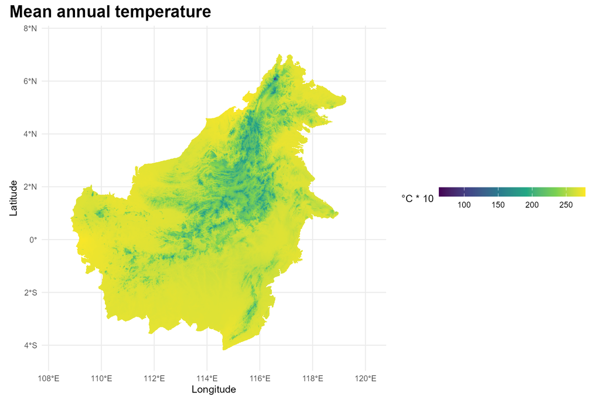

```r
g2 <- g + theme(plot.title = element_text(size = 18, face = "bold"),
                plot.title.position = "plot",
                legend.position.inside = c(0.2, 0.95),
                legend.direction = "horizontal",
                legend.key.width = unit(2.2, "lines"),
                legend.key.height = unit(0.7, "lines"))
g2
```

```r
## `ggsave()` automatically saves the last plot if not specified otherwise.
## (You can also specify a ggplot object via `plot = `).
ggsave(filename = paste0(output_wd, "/BorneoMap_4326_ggplot.png"),
       width = 8, height = 7, dpi = 600, bg = "white")
```

The saved map: check output folder

There is a new package called `tidyterra`, where *SpatRaster*-objects of `terra` can be plotted directly without the detour via `stars`. for an example see here: https://dieghernan.github.io/tidyterra/

Further beautiful ideas with ggplot for contour plots: https://eliocamp.github.io/metR/reference/geom_contour_tanaka.html

End of optional plotting.

### 3D plot with `persp()`

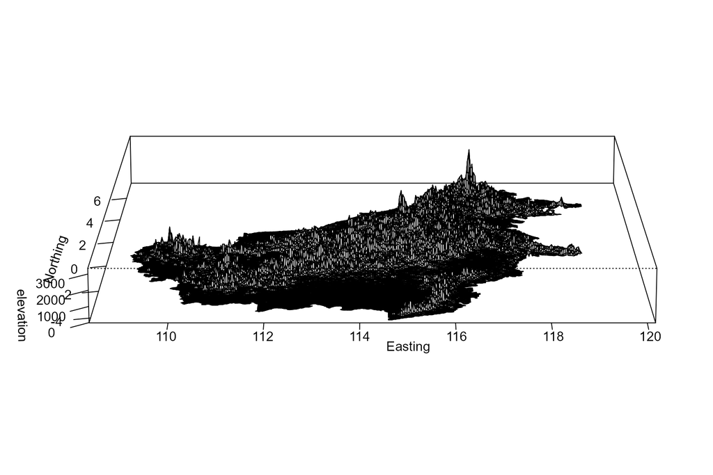

```r
# Cool 3D plots with rgl library, e.g. 'rgl.surface'
persp(x = ras_bio_asc_24, xlab = "Easting", ylab = "Northing",
      zlab = "elevation", r = 9, d = 1.5, expand = 0.1,
      ticktype = "detailed")
```

Why is the map so spiny? Check units of x, y and z coordinates! This is still a geographic CRS, not a projected one. The units are in degrees. Solution: project! (chapter: Raster projection).

## Raster projection

Project the grid (the small one!! because for large rasters it may take a long time) to have all units in meters. Remember from basics in GIS: We are now changing from angular units for the x and y coordinate (long/ lat) to a CRS where the x and y coordinates are given in meter units.

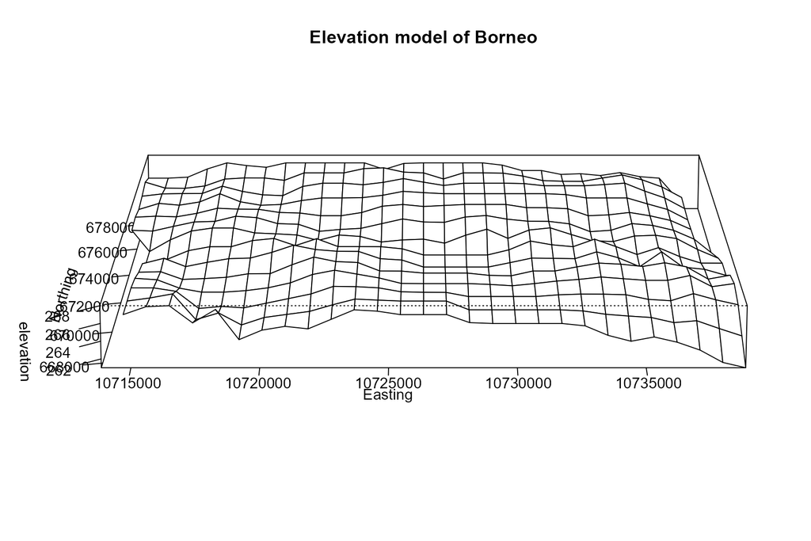

```r
Bor_dem_moll <- terra::project(ras_bio_asc_01_cr, "+proj=moll +lat_0=65 +lon_0=10")

persp(Bor_dem_moll, xlab = "Easting", ylab = "Northing",
      zlab = "elevation", main = "Elevation model of Borneo",
      r = 1, d = 5.5, expand = 0.1, ticktype = "detailed")
```

You can now try all kinds of funny projections on your own, for example, use the Albers Equal Area projection with EPSG code 3085. Give it a try:

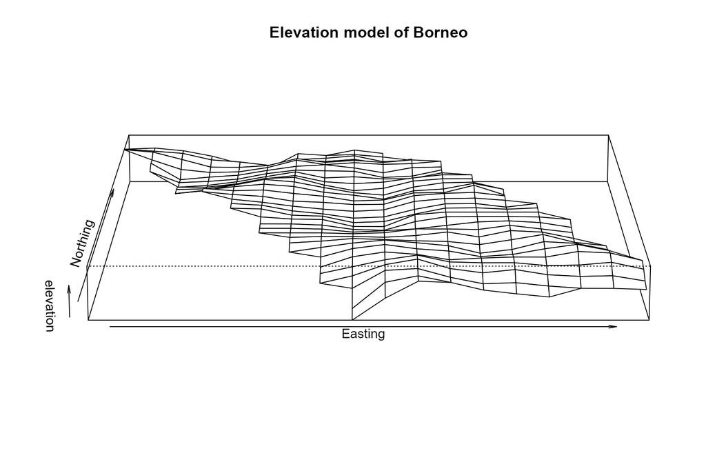

```r
Bor_dem_AEA <- terra::project(ras_bio_asc_01_cr, 'EPSG:3085')

persp(Bor_dem_AEA, xlab = "Easting", ylab = "Northing",
      zlab = "elevation", main = "Elevation model of Borneo",
      r = 1, d = 5.5, expand = 0.1)
```

## Raster Stacks

A raster stack is a collection of `SpatRaster` objects with the same spatial extent and resolution, similar to a geo-database. Go into the maps folder and check what is inside:

```r
## gives names and full path of file
files.full <- list.files(path = maps_wd, pattern = '.asc$', full.names = TRUE)
# files.full ## check also
files.full[1:3]
```

```
## [1] "C:/Users/wenzler/Documents/GitHub/d6_teaching_collection/data/data_borneo/geo_raster_current_asc/bio_asc_01.asc"
## [2] "C:/Users/wenzler/Documents/GitHub/d6_teaching_collection/data/data_borneo/geo_raster_current_asc/bio_asc_21.asc"
## [3] "C:/Users/wenzler/Documents/GitHub/d6_teaching_collection/data/data_borneo/geo_raster_current_asc/bio_asc_22.asc"
```

```r
## names only
files.rel <- list.files(path = maps_wd, pattern = '.asc$', full.names = FALSE)
files.rel[1:3]
```

```
## [1] "bio_asc_01.asc" "bio_asc_21.asc" "bio_asc_22.asc"
```

Tip of the day: Always work with the full path, as you might have stored interim results of maps with the same name in other folders than your target folder. You can avoid using the wrong maps by using the full path specification to the respective data files.

```r
predictors <- rast(x = files.full[c(1, 2, 4, 6)])
crs(predictors) #ask whether/ in which CRS the coordinates are in
```

```
## [1] "GEOGCRS[\"WGS 84 (CRS84)\",\n    DATUM[\"World Geodetic System 1984\",\n        ELLIPSOID[\"WGS 84\",6378137,298.257223563,\n            LENGTHUNIT[\"metre\",1]]],\n    PRIMEM[\"Greenwich\",0,\n        ANGLEUNIT[\"degree\",0.0174532925199433]],\n    CS[ellipsoidal,2],\n        AXIS[\"geodeti…
```

```r
## it is already assigned. If not:
#crs(predictors) <- "+proj=longlat +datum=WGS84" #or# ... <- "EPSG:4326"
```

A raster stack contains the single raster layers in a list:

```r
predictors ## this is a list! Address single layers with [[ ]]
```

```
## class       : SpatRaster
## size        : 1425, 1423, 4  (nrow, ncol, nlyr)
## resolution  : 0.008333334, 0.008333334  (x, y)
## extent      : 108.3341, 120.1925, -4.374013, 7.500988  (xmin, xmax, ymin, ymax)
## coord. ref. : lon/lat WGS 84 (CRS84) (OGC:CRS84)
## sources     : bio_asc_01.asc
##               bio_asc_21.asc
##               bio_asc_24.asc
##               bio_asc_42.asc
## names       : bio_asc_01, bio_asc_21, bio_asc_24, bio_asc_42
```

```r
predictors[[1]] ## now you address the first layer
```

```
## class       : SpatRaster
## size        : 1425, 1423, 1  (nrow, ncol, nlyr)
## resolution  : 0.008333334, 0.008333334  (x, y)
## extent      : 108.3341, 120.1925, -4.374013, 7.500988  (xmin, xmax, ymin, ymax)
## coord. ref. : lon/lat WGS 84 (CRS84) (OGC:CRS84)
## source      : bio_asc_01.asc
## name        : bio_asc_01
```

```r
## with {terra} you can also use $ syntax:
predictors$bio_asc_01
```

```
## class       : SpatRaster
## size        : 1425, 1423, 1  (nrow, ncol, nlyr)
## resolution  : 0.008333334, 0.008333334  (x, y)
## extent      : 108.3341, 120.1925, -4.374013, 7.500988  (xmin, xmax, ymin, ymax)
## coord. ref. : lon/lat WGS 84 (CRS84) (OGC:CRS84)
## source      : bio_asc_01.asc
## name        : bio_asc_01
```

### Plotting stacks

Plotting just one layer:

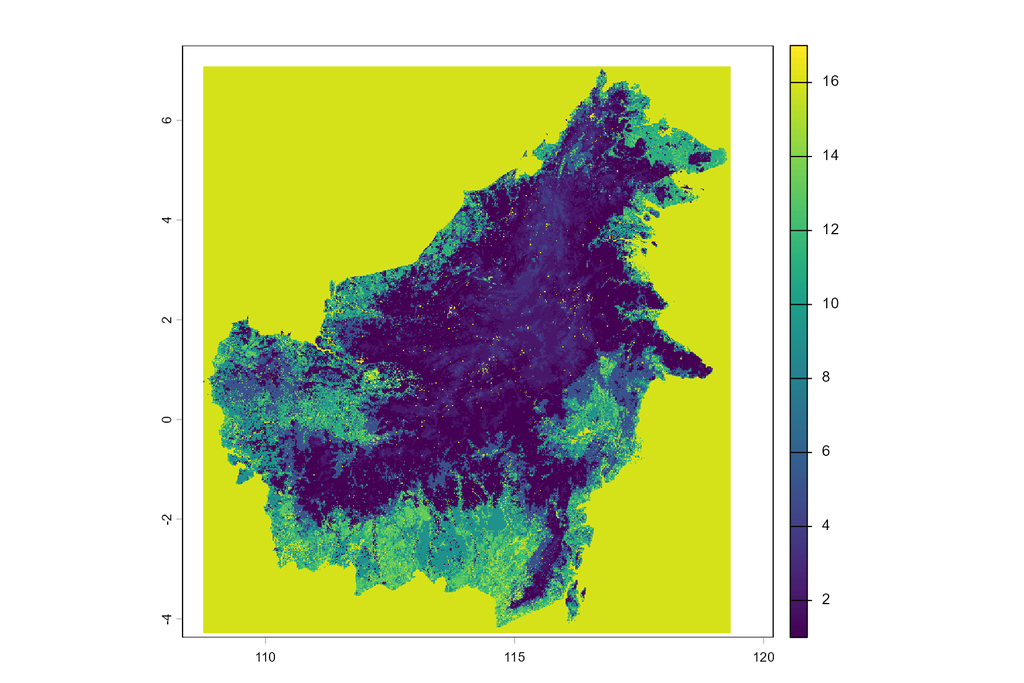

```r
plot(predictors$bio_asc_42) ## = plot(predictors[[4]])
```

Plotting all layers:

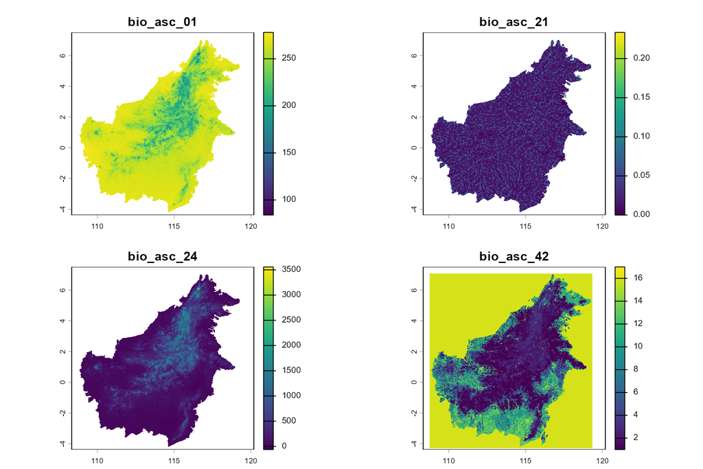

```r
plot(x = predictors)
```

Same for tmap:

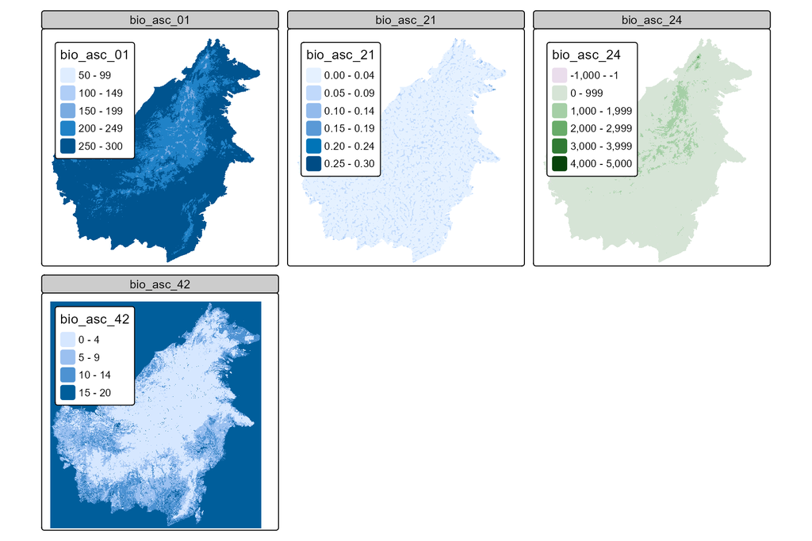

```r
tmap_mode(mode = "plot")
tm_shape(shp = predictors) + tm_raster()
```